# 01. The TransDecoder algorithm

This notebook supports two manuscript sections:

- Methods, the algorithm: `methods_algorithm.tex`
- Results, the algorithm: `results_algorithm.tex`

It draws Fig. 1 (`figures/fig1_algorithm.{pdf,png}`), and computes the bundled-presets table (Table `tab:presets`), the G+C long-ORF length table (Supplementary Table S8), the Perl/Python concordance and run-time numbers, and the frame-contrast retest in Methods.

Data are the final release runs (Perl 41fc5ee, PyTransDecoder 3a793ff; E25) wherever a final table exists. Exceptions are stated in each section. The checks at the end compare the computed values with what the manuscript says now; mismatches show where the text must change.

```r
thr <- read_tab("long_orf_threshold", "final_thresholds.tsv")
thr2017 <- read_tab("long_orf_threshold", "table_2017.tsv")
presets <- read_tab("benchmark", "presets", "bundled_presets.tsv")
ident <- read_tab("benchmark", "final_v7", "perl_pytd_identity.tsv")
scores_v7 <- read_tab("benchmark", "final_v7", "all_scores.tsv")
frames <- read_tab("benchmark", "frames", "all_scores.tsv")
frames_curve <- read_tab("benchmark", "frames", "negatives_curve.tsv")
frames_gm <- read_tab("benchmark", "frames", "gm12878_frames_protein_matches.tsv")
v7_gm <- read_tab("benchmark", "final_v7", "gm12878_v7_protein_matches.tsv")
sens_len <- read_tab("benchmark", "rules", "sens_by_length.decoy.tsv")
parity <- read_tab("benchmark", "release", "parity_perl_pytd.tsv")
reg_v6 <- read_tab("regression", "baseline_v6.0.0.summary.tsv")
reg_final <- read_tab("regression", "release_3a793ff_41fc5ee.summary.tsv")

# L*(GC) as the code looks it up: G+C rounded up to the next 5% step, the 25% value below 25%,
# no length rule above 80% (methods_algorithm.tex, GC-calibrated long-ORF rule).
lstar_lookup <- function(gc) {
  step <- pmax(25, 5 * ceiling(gc / 5 - 1e-9))
  ifelse(step > 80, NA, thr$`q0.999`[match(step, thr$gc)])
}
```

## Figure 1: the TransDecoder algorithm

Fig. 1 is a port of `figures/fig1_algorithm/make_fig1.py` (see its `NOTES.md`). Panel a is a schematic with no data; panel b is drawn from `data/long_orf_threshold/final_thresholds.tsv` (E10); panel c is the worked example of the start rule in Methods (E09).

### Panel a: workflow

The box texts follow the current Methods text. One change from `make_fig1.py`: its “Keep if any rule holds” box still gave the short-ORF rule of earlier development versions (rule 3: “if < 100 codons, also C ≥ 200 μ”). The release rule is the target-decoy q-value test (q ≤ 0.05), so the box and the “Score each ORF” box now say so (E24).

```r
BOX_FC <- c(stage = "#e8eef6", model = "#eef6ea", select = "#fbf1e3", out = "#f2f2f2")
BOX_EC <- c(stage = "#5b7fae", model = "#5f9c4e", select = "#c8892d", out = "#888888")
INK <- "#222222"; MUTED <- "#666666"; ARROW <- "#444444"
pt <- function(x) x / .pt   # font size in points -> ggplot size

bw <- 0.226; bh <- 0.40; gap <- 0.032
bx <- (0:3) * (bw + gap)
y1 <- 0.56; y2 <- 0.04
boxes <- tribble(
  ~row, ~col, ~kind, ~title, ~body,
  1, 1, "out", "Transcripts",
  "assembled transcripts (FASTA),\nor genome + transcript GTF\n-S: strand-specific data\n(forward strand only)",
  1, 2, "stage", "LongOrfs",
  "each stop paired with the most\nupstream in-frame ATG, both strands\nORFs may run off either end:\ncomplete, 5' or 3' partial, internal\nkeep ORFs of \u2265 50 codons (m)",
  1, 3, "model", "Training set",
  "candidates: 10T longest ORFs\n(T = 500), CDS \u2264 5 kb\ndrop low-complexity and\nnear-identical proteins\nkeep the T longest",
  1, 4, "model", "Self-trained models",
  "coding: 3-periodic, 5th-order\nMarkov chain vs. background\n\u03bc: median frame contrast per\nbase of the training ORFs\nKozak: start vs. internal ATGs",
  2, 1, "select", "Score each ORF",
  "S\u2081: own frame; S\u2082, S\u2083: +1, +2 nt\nS\u2084\u2013S\u2086: reverse complement\nframe contrast C = S\u2081 \u2212 max(S\u2082, S\u2083)\nq-value: C against decoy ORFs\nfrom shuffled copies of the input",
  2, 2, "select", "Keep if any rule holds",
  "1  homology hit (optional)\n2  CDS \u2265 L*(GC)  (b)\n3  S\u2081 > 0, C > 0 and q \u2264 0.05\n    (--precise 0.01, --sensitive 0.2)\nsmall inputs: preset models",
  2, 3, "select", "Rank",
  "by homology hits, then S\u2081,\nthen length\nreport the top ORF per\ntranscript (or several non-\noverlapping ORFs, optional)",
  2, 4, "stage", "Refine starts (c), output",
  "open 5' end: trim to the first\nin-frame ATG if UTR > coding\nGFF3, BED, CDS and protein\noptional: project CDS onto\nthe genome through the exons"
) %>% mutate(x0 = bx[col], x1 = x0 + bw, y0 = ifelse(row == 1, y1, y2), y1 = y0 + bh)

arrows_h <- bind_rows(lapply(c(y1, y2), function(yr) {
  ymid <- yr + bh / 2
  tibble(x = bx[1:3] + bw, xend = bx[2:4], y = ymid, yend = ymid)
}))
ym <- y1 - 0.035
xr <- bx[4] + bw / 2; xl <- bx[1] + bw / 2

pa <- ggplot() +
  geom_rect(data = boxes, aes(xmin = x0, xmax = x1, ymin = y0, ymax = y1, fill = kind, colour = kind),
            linewidth = 0.35) +
  scale_fill_manual(values = BOX_FC, guide = "none") +
  scale_colour_manual(values = BOX_EC, guide = "none") +
  geom_text(data = boxes, aes(x = x0 + 0.008, y = y1 - 0.025, label = title), hjust = 0, vjust = 1,
            size = pt(6.5), fontface = "bold", colour = INK) +
  geom_text(data = boxes, aes(x = x0 + 0.008, y = y1 - 0.095, label = body), hjust = 0, vjust = 1,
            size = pt(5.4), colour = INK, lineheight = 1.05) +
  geom_segment(data = arrows_h, aes(x = x, xend = xend, y = y, yend = yend), colour = ARROW,
               linewidth = 0.35, arrow = arrow(length = unit(1.3, "mm"), type = "closed")) +
  annotate("path", x = c(xr, xr, xl), y = c(y1, ym, ym), colour = ARROW, linewidth = 0.35) +
  annotate("segment", x = xl, xend = xl, y = ym, yend = y2 + bh, colour = ARROW, linewidth = 0.35,
           arrow = arrow(length = unit(1.3, "mm"), type = "closed")) +
  annotate("text", x = bx[2] + bw / 2, y = y2 + bh + 0.012, vjust = 0, size = pt(5.8),
           colour = MUTED, fontface = "italic",
           label = "optional: DIAMOND/BLASTP vs. proteins, hmmsearch vs. Pfam") +
  annotate("text", x = 0.5, y = -0.04, vjust = 1, size = pt(6.3), colour = MUTED,
           label = paste("Perl TransDecoder v7.0.0 and PyTransDecoder v0.2.0 implement the same",
                         "algorithm and give identical predictions")) +
  scale_x_continuous(limits = c(0, 1), expand = c(0, 0)) +
  scale_y_continuous(limits = c(-0.1, 1), expand = c(0, 0)) +
  theme_void() + labs(tag = "a") +
  theme(plot.tag = element_text(size = 9, face = "bold"))
```

```r
boxes %>% transmute(row, column = col, kind, title, text = gsub("\n", " / ", body)) %>%
  kable(caption = "Panel a: box contents") %>% kable_styling(full_width = FALSE, font_size = 12)
```

Panel a: box contents

| row | column | kind | title | text |
| --- | --- | --- | --- | --- |
| 1 | 1 | out | Transcripts | assembled transcripts (FASTA), / or genome + transcript GTF / -S: strand-specific data / (forward strand only) |
| 1 | 2 | stage | LongOrfs | each stop paired with the most / upstream in-frame ATG, both strands / ORFs may run off either end: / complete, 5’ or 3’ partial, internal / keep ORFs of ≥ 50 codons (m) |
| 1 | 3 | model | Training set | candidates: 10T longest ORFs / (T = 500), CDS ≤ 5 kb / drop low-complexity and / near-identical proteins / keep the T longest |
| 1 | 4 | model | Self-trained models | coding: 3-periodic, 5th-order / Markov chain vs. background / μ: median frame contrast per / base of the training ORFs / Kozak: start vs. internal ATGs |
| 2 | 1 | select | Score each ORF | S₁: own frame; S₂, S₃: +1, +2 nt / S₄–S₆: reverse complement / frame contrast C = S₁ − max(S₂, S₃) / q-value: C against decoy ORFs / from shuffled copies of the input |
| 2 | 2 | select | Keep if any rule holds | 1 homology hit (optional) / 2 CDS ≥ L*(GC) (b) / 3 S₁ > 0, C > 0 and q ≤ 0.05 / (–precise 0.01, –sensitive 0.2) / small inputs: preset models |
| 2 | 3 | select | Rank | by homology hits, then S₁, / then length / report the top ORF per / transcript (or several non- / overlapping ORFs, optional) |
| 2 | 4 | stage | Refine starts (c), output | open 5’ end: trim to the first / in-frame ATG if UTR > coding / GFF3, BED, CDS and protein / optional: project CDS onto / the genome through the exons |

### Panel b: GC-calibrated long-ORF length

```r
step_df <- tibble(gc = c(15, thr$gc), lstar = c(thr$`q0.999`[1], thr$`q0.999`))
orgs_b <- tibble(org = ORGS, gc = ORG_GC[ORGS]) %>%
  mutate(lstar = ifelse(org == "tthermophila", NA, lstar_lookup(gc)),
         label = ORG_LABEL[org])
lab_b <- tribble(
  ~key, ~anchor, ~dx, ~dy, ~hjust, ~text, ~face,
  "pfalciparum", "pfalciparum", 3, -260, 0.5, "P. falciparum", "italic",
  "spombe", "spombe", -2, 330, 1, "S. pombe", "italic",
  "athal", "athal", 1, -330, 0, "A. thaliana", "italic",
  "human", "dmel", -3, 540, 1, "human, mouse,", "plain",
  "creinhardtii", "creinhardtii", -2, 330, 1, "C. reinhardtii", "italic") %>%
  mutate(gc = ORG_GC[anchor], y = lstar_lookup(gc), tx = gc + dx, ty = y + dy,
         vjust = ifelse(dy > 0, 0, 1))
# geom_step(direction = "vh") reproduces matplotlib step(where = "pre")
pb <- ggplot() +
  annotate("rect", xmin = 80, xmax = 90, ymin = -Inf, ymax = Inf, fill = "#eeeeee") +
  annotate("text", x = 85, y = 1800, label = "> 80%\nG+C:\nno length\nrule", size = pt(5.2),
           colour = MUTED, lineheight = 0.95) +
  geom_step(data = step_df, aes(gc, lstar), direction = "vh", colour = TD_C, linewidth = 0.55) +
  geom_segment(data = lab_b, aes(x = tx, y = ty, xend = gc, yend = y), colour = MUTED,
               linewidth = 0.2) +
  geom_point(data = filter(orgs_b, !is.na(lstar)), aes(gc, lstar, fill = org), shape = 21,
             colour = "white", stroke = 0.25, size = 1.6) +
  scale_fill_manual(values = ORG_COLOR, guide = "none") +
  geom_text(data = lab_b, aes(x = tx, y = ty, label = text, hjust = hjust, vjust = vjust,
                              fontface = face), size = pt(5.8), colour = INK) +
  annotate("text", x = ORG_GC[["dmel"]] - 3, y = lstar_lookup(ORG_GC[["dmel"]]) + 420,
           label = "D. melanogaster", fontface = "italic", hjust = 1, vjust = 0, size = pt(5.8),
           colour = INK) +
  annotate("text", x = 16, y = 2350, hjust = 0, vjust = 1, size = pt(5.8), colour = MUTED,
           parse = TRUE, label = "italic('T. thermophila')~'(26% G+C): rule off'") +
  annotate("text", x = 16, y = 2215, hjust = 0, vjust = 1, size = pt(5.8), colour = MUTED,
           label = "(ciliate code: TGA is the only stop)") +
  scale_x_continuous(limits = c(15, 90), breaks = seq(20, 90, 10), expand = c(0, 0)) +
  scale_y_continuous(limits = c(0, 2600), expand = c(0, 0)) +
  labs(x = "transcriptome G+C (%)",
       y = expression(atop(italic(L)^"*" * ", CDS length kept", "without a coding test (nt)")),
       tag = "b") +
  theme(plot.tag = element_text(size = 9, face = "bold"))
```

```r
orgs_b %>% transmute(organism = label, `G+C of complete input (%)` = gc,
                     `L* (nt)` = ifelse(is.na(lstar), "rule off (ciliate code)", num(lstar))) %>%
  kable(caption = "Panel b: benchmark organisms placed on the lookup (step line = Supplementary Table S8)") %>%
  kable_styling(full_width = FALSE, font_size = 12)
```

Panel b: benchmark organisms placed on the lookup (step line = Supplementary Table S8)

| organism | G+C of complete input (%) | L* (nt) |
| --- | --- | --- |
| P. falciparum | 22.1 | 519 |
| T. thermophila | 25.9 | rule off (ciliate code) |
| S. pombe | 37.9 | 615 |
| A. thaliana | 42.2 | 663 |
| D. melanogaster | 50.9 | 804 |
| M. musculus | 51.7 | 804 |
| H. sapiens | 52.3 | 804 |
| C. reinhardtii | 68.3 | 1,347 |

### Panel c: start-codon refinement, worked example

```r
alpha <- 0.4; w <- 17; ulen <- 90; coding_u <- 45
base <- alpha * ulen
ex <- tibble(case = c("K = +1", "K = 0", "K = -1"), K = c(1, 0, -1), x = 0:2) %>%
  mutate(bonus = w * K, utr = base + bonus, trim = utr > coding_u,
         decision = ifelse(trim, "trim", "keep\npartial"))
bwid <- 0.55
# hatch for the negative Kozak term: diagonal lines clipped to the rectangle
hatch <- function(x0, x1, y0, y1, s = 40, step = 7) {
  cs <- seq(y0 - s * x1, y1 - s * x0, by = step)
  bind_rows(lapply(cs, function(c) {
    xa <- max(x0, (y0 - c) / s); xb <- min(x1, (y1 - c) / s)
    if (xa >= xb) return(NULL)
    tibble(x = xa, xend = xb, y = c + s * xa, yend = c + s * xb)
  }))
}
neg <- filter(ex, bonus < 0)
hat <- hatch(neg$x - bwid / 2, neg$x + bwid / 2, neg$utr, base)

pc_bot <- ggplot(ex) +
  geom_rect(aes(xmin = x - bwid / 2, xmax = x + bwid / 2, ymin = 0, ymax = pmin(base, utr)),
            fill = "#fbe3c6", colour = "#c8892d", linewidth = 0.3) +
  geom_rect(data = filter(ex, bonus > 0), aes(xmin = x - bwid / 2, xmax = x + bwid / 2,
            ymin = base, ymax = utr), fill = "#c8892d") +
  geom_rect(data = neg, aes(xmin = x - bwid / 2, xmax = x + bwid / 2, ymin = utr, ymax = base),
            fill = "white", colour = "#c8892d", linewidth = 0.3) +
  geom_segment(data = hat, aes(x = x, xend = xend, y = y, yend = yend), colour = "#c8892d",
               linewidth = 0.25) +
  geom_hline(yintercept = coding_u, colour = TD_C, linewidth = 0.45, linetype = "dashed") +
  geom_text(aes(x = x, y = pmax(utr, base) + 2, label = utr), vjust = 0, size = pt(6.3)) +
  geom_text(aes(x = x, y = -9, label = decision, colour = trim), vjust = 1, size = pt(6),
            fontface = "bold", lineheight = 0.9) +
  scale_colour_manual(values = c(`TRUE` = TD_C, `FALSE` = MUTED), guide = "none") +
  annotate("text", x = 2.9, y = coding_u + 1.5, label = "coding(u) = 45", colour = TD_C,
           hjust = 1, vjust = 0, size = pt(6)) +
  annotate("text", x = 2.33, y = base / 2, label = "\u03b1|u| = 36", hjust = 0, size = pt(5.8),
           colour = MUTED) +
  annotate("text", x = 0, y = base + w / 2 - 2, label = "+wK", colour = "white", size = pt(5.8),
           fontface = "italic") +
  annotate("text", x = 2.33, y = base - w / 2, label = "wK < 0", hjust = 0, size = pt(5.8),
           colour = MUTED) +
  scale_x_continuous(breaks = ex$x, labels = ex$case, expand = c(0, 0)) +
  scale_y_continuous(expand = c(0, 0)) +
  coord_cartesian(xlim = c(-0.5, 2.9), ylim = c(0, 62), clip = "off") +
  labs(x = NULL, y = "UTR(u)\n(bases of coding signal)",
       title = "example: |u| = 90, coding(u) = 45;  \u03b1 = 0.4, w = 17 bases per bit") +
  theme(axis.ticks.x = element_blank(), plot.margin = margin(2, 2, 22, 2),
        plot.title = element_text(size = 5.8, colour = MUTED, hjust = 0.5))

yy <- 4.2
pc_top <- ggplot() +
  annotate("segment", x = 2, xend = 6, y = yy, yend = yy, colour = "#888888", linewidth = 0.55,
           linetype = "11") +
  annotate("rect", xmin = 6, xmax = 32, ymin = yy - 1.6, ymax = yy + 1.6, fill = "#fbe3c6",
           colour = "#c8892d", linewidth = 0.3) +
  annotate("rect", xmin = 32, xmax = 92, ymin = yy - 1.6, ymax = yy + 1.6, fill = "#c6d8ee",
           colour = TD_C, linewidth = 0.3) +
  annotate("segment", x = 92, xend = 98, y = yy, yend = yy, colour = "#888888", linewidth = 0.55) +
  annotate("segment", x = 32, xend = 32, y = yy - 1.6, yend = yy + 2.0, colour = INK,
           linewidth = 0.35) +
  annotate("text", x = 19, y = yy, label = "u  (90 nt)", size = pt(6.3)) +
  annotate("text", x = 62, y = yy, label = "ORF continues to the stop codon", size = pt(6)) +
  annotate("text", x = 32, y = yy + 2.2, label = "first in-frame ATG", vjust = 0, size = pt(6)) +
  annotate("text", x = 4, y = yy + 2.2, label = "open 5' end", vjust = 0, size = pt(6),
           colour = MUTED) +
  annotate("text", x = 50, y = 0.2, vjust = 0, size = pt(6.3),
           label = "trim to the ATG if  UTR(u) = \u03b1|u| + wK  >  coding(u) = C(u)/\u03bc") +
  scale_x_continuous(limits = c(0, 100), expand = c(0, 0)) +
  scale_y_continuous(limits = c(0, 10), expand = c(0, 0)) +
  coord_cartesian(clip = "off") +
  theme_void() + labs(tag = "c") +
  theme(plot.tag = element_text(size = 9, face = "bold"))
```

```r
ex %>% transmute(Kozak = case, `K (bits)` = K, `alpha|u|` = base, `wK` = bonus, `UTR(u)` = utr,
                 `coding(u)` = coding_u, decision = gsub("\n", " ", decision)) %>%
  kable(caption = "Panel c: UTR and coding scores of the 90-nt example") %>%
  kable_styling(full_width = FALSE, font_size = 12)
```

Panel c: UTR and coding scores of the 90-nt example

| Kozak | K (bits) | alpha&#124;u&#124; | wK | UTR(u) | coding(u) | decision |
| --- | --- | --- | --- | --- | --- | --- |
| K = +1 | 1 | 36 | 17 | 53 | 45 | trim |
| K = 0 | 0 | 36 | 0 | 36 | 45 | keep partial |
| K = -1 | -1 | 36 | -17 | 19 | 45 | keep partial |

### Assembled figure

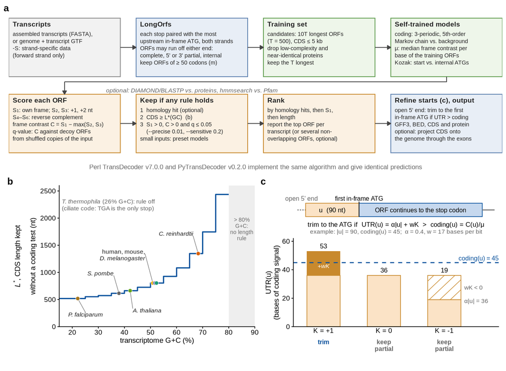

```r
fig1 <- wrap_elements(full = pa) / (pb + (pc_top / pc_bot + plot_layout(heights = c(1, 2.1))) +
              plot_layout(widths = c(1, 1.05))) +
  plot_layout(heights = c(1.15, 1))
save_fig(fig1, "fig1_algorithm", width = FULL_W, height = 125 * MM)
fig1
```

## Workflow (Results, first paragraph)

The first Results paragraph and Fig. 1a quote these settings. They are defaults in the code, not measured values; they are checked here against the Methods text.

```r
settings <- tibble(
  setting = c("minimum ORF length m (codons)", "training candidates 10T, T", "max training CDS (nt)",
              "default q_max", "--precise q_max", "--sensitive q_max", "bundled presets",
              "start rule alpha", "Kozak weight w (bases per bit)"),
  value = c(50, 500, 5000, 0.05, 0.01, 0.2, nrow(presets), alpha, w))
kable(settings) %>% kable_styling(full_width = FALSE, font_size = 12)
```

| setting | value |
| --- | --- |
| minimum ORF length m (codons) | 50.00 |
| training candidates 10T, T | 500.00 |
| max training CDS (nt) | 5000.00 |
| default q_max | 0.05 |
| –precise q_max | 0.01 |
| –sensitive q_max | 0.20 |
| bundled presets | 7.00 |
| start rule alpha | 0.40 |
| Kozak weight w (bases per bit) | 17.00 |

Seven presets are distributed (7 in the release packages; E24).

## GC-calibrated long-ORF rule

$L^\ast$ is the 0.999 quantile of ORF lengths in i.i.d. random sequence, simulated in 5% G+C steps (E10). It rises from 519 nt at 25% G+C to 2,436 nt at 80%. Each level has at least 85,056 random ORFs. The table below is Supplementary Table S8, with the 2017 table it replaces.

```r
lt <- thr %>% left_join(thr2017 %>% select(gc, q2017 = `q0.999`), by = "gc") %>%
  mutate(diff_pct = 100 * (q2017 - `q0.999`) / `q0.999`)
lt %>% transmute(`G+C (%)` = gc, `random ORFs` = num(n_orfs), `q0.95` = `q0.95`, `q0.99` = `q0.99`,
                 `L* = q0.999 (nt)` = `q0.999`, `q0.9999` = `q0.9999`,
                 `2017 q0.999` = round(q2017), `2017 vs L* (%)` = round(diff_pct, 1)) %>%
  kable(caption = "Long-ORF length by G+C (Supplementary Table S8)") %>%
  kable_styling(full_width = FALSE, font_size = 12)
```

Long-ORF length by G+C (Supplementary Table S8)

| G+C (%) | random ORFs | q0.95 | q0.99 | L* = q0.999 (nt) | q0.9999 | 2017 q0.999 | 2017 vs L* (%) |
| --- | --- | --- | --- | --- | --- | --- | --- |
| 25 | 85,915 | 396 | 447 | 519 | 580.2 | 465 | -10.3 |
| 30 | 85,056 | 408 | 462 | 552 | 621.0 | 511 | -7.4 |
| 35 | 101,458 | 417 | 483 | 573 | 663.0 | 555 | -3.2 |
| 40 | 115,742 | 435 | 507 | 615 | 707.6 | 590 | -4.1 |
| 45 | 150,612 | 456 | 540 | 663 | 767.8 | 645 | -2.8 |
| 50 | 103,782 | 483 | 585 | 726 | 852.0 | 749 | 3.1 |
| 55 | 200,546 | 522 | 639 | 804 | 978.0 | 797 | -0.9 |
| 60 | 357,795 | 570 | 714 | 927 | 1149.7 | 927 | 0.0 |
| 65 | 584,858 | 642 | 822 | 1083 | 1356.1 | 1086 | 0.3 |
| 70 | 860,669 | 750 | 993 | 1347 | 1706.8 | 1358 | 0.8 |
| 75 | 1,121,478 | 924 | 1257 | 1746 | 2202.0 | 1743 | -0.2 |
| 80 | 1,264,679 | 1233 | 1731 | 2436 | 3153.0 | 2423 | -0.5 |

### Effect of the rule on long true CDSs

Methods says that without this rule, stop-level sensitivity for true CDSs of at least 400 codons on complete transcripts falls from 0.998 to 0.995 with the q-value test alone. This uses the development runs of E20 (`data/benchmark/rules/sens_by_length.decoy.tsv`, complete transcripts with random negatives, pooled over the eight organisms); no equivalent table exists for the final runs. “0.998” is the earlier release rule (`cliff_c200`, which has the long-ORF rule) and “0.995” the decoy rule without it (`decoy_q0.05`).

```r
long <- sens_len %>% filter(variant == "complete.wRand", set == "coding", length_bin == ">=400") %>%
  group_by(label) %>% summarise(n = sum(n), hits = sum(hits), .groups = "drop") %>%
  mutate(sensitivity = hits / n)
sens_with <- long$sensitivity[long$label == "cliff_c200"]
sens_without <- long$sensitivity[long$label == "decoy_q0.05"]
kable(long, digits = 4) %>% kable_styling(full_width = FALSE, font_size = 12)
```

| label | n | hits | sensitivity |
| --- | --- | --- | --- |
| cliff_c200 | 70651 | 70526 | 0.9982 |
| decoy_q0.05 | 70651 | 70296 | 0.9950 |
| decoy_q0.1 | 70651 | 70296 | 0.9950 |
| decoy_q0.2 | 70651 | 70296 | 0.9950 |
| taper_c150 | 70651 | 70530 | 0.9983 |
| taper_c200 | 70651 | 70531 | 0.9983 |

With the long-ORF rule 0.998; q-value test alone 0.995.

## Start-codon refinement example

For |u| = 90 nt, α = 0.4 and w = 17, the baseline is 36. A segment with coding score 45 is trimmed with K = +1 (UTR score 53) and kept partial with K = 0 (36) or K = −1 (19) (E09, E13).

## Frame contrast: forward frames only or all five frames

Methods retests the contrast against all five other frames, $C=S_1-\max(S_2,\dots,S_6)$, with the q-value test (E26). Runs: PyTD 83a4806 (`--contrast-frames all`) against the release `pytd_v7` on all 84 benchmark inputs (`data/benchmark/frames/`).

### At the same q (0.05)

```r
fr <- frames %>% select(org, variant, tool, f1_stop, f1_exact, sensitivity_stop, precision_stop,
                        runtime_sec) %>%
  pivot_wider(names_from = tool, values_from = c(f1_stop, f1_exact, sensitivity_stop,
                                                 precision_stop, runtime_sec)) %>%
  mutate(d_exact = 100 * (f1_exact_all - f1_exact_pytd_v7),
         d_stop = 100 * (f1_stop_all - f1_stop_pytd_v7),
         type = sub("\\..*", "", variant),
         stranded = !grepl("unstranded", variant),
         runtime_ratio = runtime_sec_all / runtime_sec_pytd_v7)
n_worse <- sum(fr$d_exact < 0); n_better <- sum(fr$d_exact > 0)
med_d_exact <- median(fr$d_exact)
frag <- fr %>% filter(type == "fragments")
med_frag_d <- median(frag$d_exact)
cls <- fr %>% mutate(cls = paste0(type, ifelse(stranded, " (stranded)", " (unstranded)"))) %>%
  group_by(cls) %>%
  summarise(n = n(), across(c(f1_stop_all, f1_stop_pytd_v7, f1_exact_all, f1_exact_pytd_v7),
                            median), med_d_exact = median(d_exact), .groups = "drop") %>%
  mutate(d_of_medians = 100 * (f1_exact_all - f1_exact_pytd_v7))
tth_frag <- fr$d_exact[fr$org == "tthermophila" & fr$variant == "fragments"]
worst <- fr %>% arrange(d_exact) %>% slice(1:3) %>% select(org, variant, d_exact)
rt_ratio <- median(fr$runtime_ratio)
kable(cls, digits = 3, caption = "Medians by input class, all-frames vs release (q 0.05)") %>%
  kable_styling(full_width = FALSE, font_size = 12)
```

Medians by input class, all-frames vs release (q 0.05)

| cls | n | f1_stop_all | f1_stop_pytd_v7 | f1_exact_all | f1_exact_pytd_v7 | med_d_exact | d_of_medians |
| --- | --- | --- | --- | --- | --- | --- | --- |
| complete (stranded) | 18 | 0.976 | 0.977 | 0.905 | 0.907 | -0.140 | -0.145 |
| complete (unstranded) | 16 | 0.975 | 0.976 | 0.905 | 0.906 | -0.105 | -0.070 |
| complete_fullutr (stranded) | 8 | 0.969 | 0.973 | 0.902 | 0.904 | -0.270 | -0.225 |
| complete_fullutr (unstranded) | 8 | 0.959 | 0.962 | 0.887 | 0.890 | -0.200 | -0.360 |
| fragments (stranded) | 18 | 0.919 | 0.928 | 0.800 | 0.817 | -1.440 | -1.715 |
| fragments (unstranded) | 16 | 0.908 | 0.917 | 0.789 | 0.806 | -1.195 | -1.775 |

```r
kable(worst, digits = 2, caption = "Largest exact-F1 losses (points)") %>%
  kable_styling(full_width = FALSE, font_size = 12)
```

Largest exact-F1 losses (points)

| org | variant | d_exact |
| --- | --- | --- |
| tthermophila | fragments | -7.71 |
| tthermophila | fragments.wRand | -3.04 |
| mouse | fragments.unstranded | -2.06 |

All-frames lowered exact-CDS F1 on 75 of 84 inputs (raised it on 9; median -0.33 points). On fragment inputs the median change is -1.41 points; the difference of class medians, which is what the text quotes (“fragments −1.7 points”), is -1.71 (stranded) and -1.78 (unstranded) points. The largest loss is *T. thermophila* fragments, -7.7 points. All-frames took a median 1.41 times the release run time.

**Per-input exact F1 (84 inputs)**

```r
fr %>% select(org, variant, f1_exact_pytd_v7, f1_exact_all, d_exact, runtime_ratio) %>%
  kable(digits = 3) %>% kable_styling(full_width = FALSE, font_size = 11)
```

| org | variant | f1_exact_pytd_v7 | f1_exact_all | d_exact | runtime_ratio |
| --- | --- | --- | --- | --- | --- |
| athal | complete_fullutr.unstranded | 0.888 | 0.883 | -0.54 | 1.687 |
| athal | complete_fullutr | 0.896 | 0.891 | -0.45 | 1.672 |
| athal | complete | 0.899 | 0.895 | -0.37 | 1.674 |
| athal | complete.unstranded | 0.892 | 0.887 | -0.57 | 1.628 |
| athal | complete.wRand | 0.897 | 0.893 | -0.41 | 1.642 |
| athal | complete.unstranded.wRand | 0.890 | 0.885 | -0.46 | 1.540 |
| athal | fragments | 0.753 | 0.737 | -1.62 | 1.584 |
| athal | fragments.unstranded | 0.733 | 0.717 | -1.58 | 1.584 |
| athal | fragments.unstranded.wRand | 0.729 | 0.712 | -1.71 | 1.580 |
| creinhardtii | complete_fullutr | 0.733 | 0.731 | -0.18 | 1.422 |
| athal | fragments.wRand | 0.750 | 0.734 | -1.65 | 1.530 |
| creinhardtii | complete_fullutr.unstranded | 0.729 | 0.727 | -0.24 | 1.571 |
| creinhardtii | complete | 0.747 | 0.746 | -0.13 | 1.516 |
| creinhardtii | complete.unstranded | 0.742 | 0.742 | 0.01 | 1.637 |
| creinhardtii | complete.unstranded.wRand | 0.739 | 0.739 | 0.07 | 1.698 |
| creinhardtii | complete.wRand | 0.746 | 0.744 | -0.15 | 1.685 |
| creinhardtii | fragments | 0.778 | 0.776 | -0.18 | 1.885 |
| creinhardtii | fragments.unstranded | 0.770 | 0.773 | 0.27 | 1.782 |
| creinhardtii | fragments.unstranded.wRand | 0.769 | 0.771 | 0.19 | 1.726 |
| creinhardtii | fragments.wRand | 0.778 | 0.775 | -0.21 | 1.707 |
| dmel | complete_fullutr | 0.915 | 0.914 | -0.15 | 1.462 |
| dmel | complete_fullutr.unstranded | 0.911 | 0.910 | -0.03 | 1.543 |
| dmel | complete | 0.928 | 0.927 | -0.10 | 1.392 |
| dmel | complete.unstranded | 0.926 | 0.924 | -0.19 | 1.381 |
| dmel | complete.unstranded.wRand | 0.924 | 0.923 | -0.12 | 1.392 |
| dmel | complete.wRand | 0.925 | 0.924 | -0.11 | 1.414 |
| dmel | fragments | 0.841 | 0.836 | -0.47 | 1.331 |
| dmel | fragments.unstranded | 0.833 | 0.827 | -0.62 | 1.541 |
| dmel | fragments.unstranded.wRand | 0.828 | 0.824 | -0.48 | 1.321 |
| dmel | fragments.wRand | 0.838 | 0.832 | -0.59 | 1.164 |

[output cut: 54 more lines]

### At equal rates of predictions on negative sequences

Medians over organisms of stop sensitivity and % of negatives with a call, for each q. The release curve (q 0.01, 0.05, 0.2) is interpolated linearly at the all-frames points.

```r
cm <- frames_curve %>% group_by(variant, label) %>%
  summarise(sens = median(sens_stop), neg_pct = 100 * median(neg_rate), n = n(), .groups = "drop") %>%
  mutate(rule = ifelse(grepl("^fwd", label), "release", "all"))
interp <- cm %>% filter(rule == "all") %>% rowwise() %>%
  mutate(release_at_same_neg = {
    r <- cm %>% filter(variant == .env$variant, rule == "release") %>% arrange(neg_pct)
    if (nrow(r) < 2 || neg_pct < min(r$neg_pct) || neg_pct > max(r$neg_pct)) NA_real_ else
      approx(r$neg_pct, r$sens, xout = neg_pct, ties = "ordered")$y
  }) %>% ungroup() %>% mutate(diff_pts = 100 * (release_at_same_neg - sens))
kable(cm %>% arrange(variant, rule, label), digits = 3,
      caption = "Medians over organisms") %>% kable_styling(full_width = FALSE, font_size = 12)
```

Medians over organisms

| variant | label | sens | neg_pct | n | rule |
| --- | --- | --- | --- | --- | --- |
| complete.unstranded.wRand | all_q0.05 | 0.957 | 0.250 | 8 | all |
| complete.unstranded.wRand | all_q0.1 | 0.960 | 0.265 | 8 | all |
| complete.unstranded.wRand | all_q0.2 | 0.964 | 0.330 | 8 | all |
| complete.unstranded.wRand | fwd_q0.05 | 0.961 | 0.390 | 8 | release |
| complete.wLnc | all_q0.05 | 0.958 | 4.540 | 2 | all |
| complete.wLnc | all_q0.1 | 0.965 | 5.440 | 2 | all |
| complete.wLnc | all_q0.2 | 0.972 | 7.055 | 2 | all |
| complete.wLnc | fwd_q0.01 | 0.950 | 4.250 | 2 | release |
| complete.wLnc | fwd_q0.05 | 0.963 | 5.040 | 2 | release |
| complete.wLnc | fwd_q0.2 | 0.974 | 7.800 | 2 | release |
| complete.wRand | all_q0.05 | 0.960 | 0.210 | 8 | all |
| complete.wRand | all_q0.1 | 0.964 | 0.265 | 8 | all |
| complete.wRand | all_q0.2 | 0.966 | 0.310 | 8 | all |
| complete.wRand | fwd_q0.01 | 0.955 | 0.285 | 8 | release |
| complete.wRand | fwd_q0.05 | 0.964 | 0.285 | 8 | release |
| complete.wRand | fwd_q0.2 | 0.971 | 0.405 | 8 | release |
| fragments.unstranded.wRand | all_q0.05 | 0.836 | 0.275 | 8 | all |
| fragments.unstranded.wRand | all_q0.1 | 0.858 | 0.320 | 8 | all |
| fragments.unstranded.wRand | all_q0.2 | 0.866 | 0.490 | 8 | all |
| fragments.unstranded.wRand | fwd_q0.05 | 0.859 | 0.315 | 8 | release |
| fragments.wLnc | all_q0.05 | 0.816 | 5.075 | 2 | all |
| fragments.wLnc | all_q0.1 | 0.850 | 6.365 | 2 | all |
| fragments.wLnc | all_q0.2 | 0.881 | 8.750 | 2 | all |
| fragments.wLnc | fwd_q0.01 | 0.794 | 4.565 | 2 | release |
| fragments.wLnc | fwd_q0.05 | 0.858 | 5.890 | 2 | release |
| fragments.wLnc | fwd_q0.2 | 0.906 | 10.235 | 2 | release |
| fragments.wRand | all_q0.05 | 0.856 | 0.200 | 8 | all |
| fragments.wRand | all_q0.1 | 0.869 | 0.235 | 8 | all |
| fragments.wRand | all_q0.2 | 0.878 | 0.380 | 8 | all |
| fragments.wRand | fwd_q0.01 | 0.837 | 0.170 | 8 | release |
| fragments.wRand | fwd_q0.05 | 0.872 | 0.225 | 8 | release |
| fragments.wRand | fwd_q0.2 | 0.895 | 0.445 | 8 | release |

```r
kable(interp %>% select(variant, label, neg_pct, sens, release_at_same_neg, diff_pts), digits = 3,
      caption = "Release sensitivity at the all-frames negative rate (points: release minus all-frames)") %>%
  kable_styling(full_width = FALSE, font_size = 12)
```

Release sensitivity at the all-frames negative rate (points: release minus all-frames)

| variant | label | neg_pct | sens | release_at_same_neg | diff_pts |
| --- | --- | --- | --- | --- | --- |
| complete.unstranded.wRand | all_q0.05 | 0.250 | 0.957 | NA | NA |
| complete.unstranded.wRand | all_q0.1 | 0.265 | 0.960 | NA | NA |
| complete.unstranded.wRand | all_q0.2 | 0.330 | 0.964 | NA | NA |
| complete.wLnc | all_q0.05 | 4.540 | 0.958 | 0.954 | -0.397 |
| complete.wLnc | all_q0.1 | 5.440 | 0.965 | 0.964 | -0.118 |
| complete.wLnc | all_q0.2 | 7.055 | 0.972 | 0.971 | -0.061 |
| complete.wRand | all_q0.05 | 0.210 | 0.960 | NA | NA |
| complete.wRand | all_q0.1 | 0.265 | 0.964 | NA | NA |
| complete.wRand | all_q0.2 | 0.310 | 0.966 | 0.965 | -0.111 |
| fragments.unstranded.wRand | all_q0.05 | 0.275 | 0.836 | NA | NA |
| fragments.unstranded.wRand | all_q0.1 | 0.320 | 0.858 | NA | NA |
| fragments.unstranded.wRand | all_q0.2 | 0.490 | 0.866 | NA | NA |
| fragments.wLnc | all_q0.05 | 5.075 | 0.816 | 0.819 | 0.244 |
| fragments.wLnc | all_q0.1 | 6.365 | 0.850 | 0.864 | 1.390 |
| fragments.wLnc | all_q0.2 | 8.750 | 0.881 | 0.890 | 0.888 |
| fragments.wRand | all_q0.05 | 0.200 | 0.856 | 0.856 | -0.039 |
| fragments.wRand | all_q0.1 | 0.235 | 0.869 | 0.873 | 0.389 |
| fragments.wRand | all_q0.2 | 0.380 | 0.878 | 0.888 | 1.054 |

```r
frag_str_gain <- interp %>% filter(variant %in% c("fragments.wRand", "fragments.wLnc"),
                                   !is.na(diff_pts)) %>% pull(diff_pts)
cmp_gain <- interp %>% filter(variant %in% c("complete.wRand", "complete.wLnc"), !is.na(diff_pts)) %>%
  pull(diff_pts)
```

On stranded fragments the release rule is ahead by 0.2, 1.4, 0.9, -0.0, 0.4, 1.1 points at the matched all-frames points; on complete transcripts the differences are -0.4, -0.1, -0.1, -0.1 points. Unstranded inputs have only the release default (q 0.05), so they are compared at that point in E26 only.

### GM12878

```r
gm <- bind_rows(
  frames_gm %>% filter(!grepl("sensitive", label)) %>% mutate(asm = sub("\\..*", "", label), rule = "all"),
  v7_gm %>% filter(grepl("v7_default", label)) %>% mutate(asm = sub("\\..*", "", label), rule = "release")) %>%
  select(asm, rule, true_positives, nonmatching) %>%
  pivot_wider(names_from = rule, values_from = c(true_positives, nonmatching)) %>%
  mutate(lost_matching = true_positives_release - true_positives_all,
         removed_nonmatching = nonmatching_release - nonmatching_all)
kable(gm, caption = "Matching / non-matching proteins (GENCODE v50), all-frames vs release default") %>%
  kable_styling(full_width = FALSE, font_size = 12)
```

Matching / non-matching proteins (GENCODE v50), all-frames vs release default

| asm | true_positives_all | true_positives_release | nonmatching_all | nonmatching_release | lost_matching | removed_nonmatching |
| --- | --- | --- | --- | --- | --- | --- |
| lraa | 32445 | 32751 | 280 | 277 | 306 | -3 |
| stringtie | 34709 | 35294 | 1017 | 1185 | 585 | 168 |
| trinity | 75955 | 78181 | 2317 | 2616 | 2226 | 299 |

All-frames removed 306–2,226 proteins that match GENCODE for at most 299 non-matching ones.

## Presets for small inputs (Table tab:presets)

The seven bundled presets, read from the release packages by `pipeline/derive/01_bundled_presets.py` (`data/benchmark/presets/bundled_presets.tsv`; E21, E24). All files of every preset are byte-identical in the Perl and Python packages: TRUE. The last column re-derives $L^\ast$ from the preset’s G+C with the lookup above.

```r
ms_presets <- tibble(  # Table tab:presets as written in methods_algorithm.tex l.224-230
  name = c("mammal", "insect", "plant", "fungus", "apicomplexan", "ciliate", "green_alga"),
  ms_gc = c(49.8, 50.8, 42.1, 37.8, 22.0, 25.9, 68.2),
  ms_lstar = c(726, 804, 663, 615, 519, NA, 1347))
pt_tab <- presets %>% left_join(ms_presets, by = "name") %>%
  mutate(lstar_num = suppressWarnings(as.numeric(auto_accept_nt)),
         lstar_lookup = ifelse(genetic_code == "Universal", lstar_lookup(gc_pct), NA))
pt_tab %>% transmute(Preset = name, Reference = sub(" benchmark annotation.*", "", source),
                     `Genetic code` = genetic_code, `G+C (%)` = round(gc_pct, 1),
                     `L* (nt)` = auto_accept_nt, `L* from lookup` = lstar_lookup,
                     `q levels` = paste0(n_q_levels, " (", q_min, "-", q_max, ")"),
                     strata = n_strata, `training ORFs` = n_training_orfs,
                     `Perl = Python` = perl_py_identical) %>%
  kable(caption = "Bundled presets (Table tab:presets)") %>%
  kable_styling(full_width = FALSE, font_size = 12)
```

Bundled presets (Table tab:presets)

| Preset | Reference | Genetic code | G+C (%) | L* (nt) | L* from lookup | q levels | strata | training ORFs | Perl = Python |
| --- | --- | --- | --- | --- | --- | --- | --- | --- | --- |
| mammal | human | Universal | 49.8 | 726 | 726 | 10 (0.001-0.5) | 425 | 500 | TRUE |
| insect | dmel | Universal | 50.8 | 804 | 804 | 10 (0.001-0.5) | 249 | 500 | TRUE |
| plant | athal | Universal | 42.1 | 663 | 663 | 10 (0.001-0.5) | 224 | 500 | TRUE |
| fungus | spombe | Universal | 37.8 | 615 | 615 | 10 (0.001-0.5) | 187 | 500 | TRUE |
| apicomplexan | pfalciparum | Universal | 22.0 | 519 | 519 | 10 (0.001-0.5) | 220 | 500 | TRUE |
| ciliate | tthermophila | Tetrahymena | 25.9 | none | NA | 10 (0.001-0.5) | 308 | 500 | TRUE |
| green_alga | creinhardtii | Universal | 68.2 | 1347 | 1347 | 10 (0.001-0.5) | 282 | 500 | TRUE |

Every preset stores 10 q levels from 0.001 to 0.5.

## Two implementations with identical output

### Benchmark: 84 inputs at the release commits

`pipeline/derive/01_perl_pytd_identity.py` compares the predictions (transcript, start, end, strand) of `perl_td_v7` and `pytd_v7` on every benchmark input (E25).

```r
n_ident <- sum(ident$identical); n_inputs <- nrow(ident)
ident <- ident %>% mutate(ratio = perl_runtime_sec / pytd_runtime_sec)
rt_med <- median(ident$ratio); rt_rng <- range(ident$ratio)
# all_scores.tsv: the score rows of the two tools must then also agree
sc_same <- scores_v7 %>% filter(tool %in% c("perl_td_v7", "pytd_v7")) %>%
  select(org, variant, tool, n_pred, tp_stop, tp_exact, fp) %>%
  pivot_wider(names_from = tool, values_from = c(n_pred, tp_stop, tp_exact, fp)) %>%
  summarise(all_same = all(n_pred_perl_td_v7 == n_pred_pytd_v7 & tp_stop_perl_td_v7 == tp_stop_pytd_v7 &
                           tp_exact_perl_td_v7 == tp_exact_pytd_v7 & fp_perl_td_v7 == fp_pytd_v7))
# development versions quoted in the current text (E07/E08: pytd_dev_v2 vs perl_td_dev_v2)
dev_rt <- scores_v7 %>% filter(tool %in% c("perl_td_dev_v2", "pytd_dev_v2")) %>%
  select(org, variant, tool, runtime_sec) %>% pivot_wider(names_from = tool, values_from = runtime_sec) %>%
  mutate(ratio = perl_td_dev_v2 / pytd_dev_v2)
dev_med <- median(dev_rt$ratio); dev_rng <- range(dev_rt$ratio)
v7_vs_dev <- scores_v7 %>% filter(tool %in% c("pytd_v7", "pytd_dev_v2")) %>%
  select(org, variant, tool, runtime_sec) %>% pivot_wider(names_from = tool, values_from = runtime_sec) %>%
  summarise(median_ratio = median(pytd_v7 / pytd_dev_v2))
```

Predictions are identical on 84 of 84 inputs, with 0 implementation-only predictions in total; the scores in `all_scores.tsv` agree on every input (TRUE).

Run time (wall clock on a shared host, single thread): PyTransDecoder was a median 2.71 times faster than Perl (range 2.07–3.28). The current text quotes the development versions (`pytd_dev_v2` vs `perl_td_dev_v2`): median 2.29 (range 1.99–2.51). The release PyTD took a median 1.75 times as long as the development version, mostly for the decoy step.

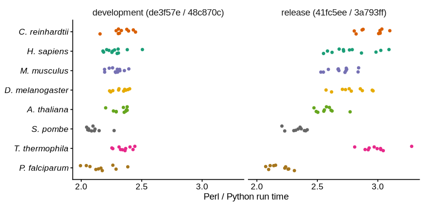

```r
rt_long <- bind_rows(ident %>% transmute(org, ratio, version = "release (41fc5ee / 3a793ff)"),
                     dev_rt %>% transmute(org, ratio, version = "development (de3f57e / 48c870c)"))
ggplot(rt_long, aes(ratio, org_factor(org), colour = org)) +
  geom_jitter(height = 0.15, width = 0, size = 0.8) +
  facet_wrap(~version) + scale_colour_manual(values = ORG_COLOR, guide = "none") +
  labs(x = "Perl / Python run time", y = NULL) +
  theme(axis.text.y = element_text(face = "italic"))
```

**Per-input identity and run times (84 inputs)**

```r
ident %>% kable(digits = 2) %>% kable_styling(full_width = FALSE, font_size = 11)
```

| org | variant | n_perl | n_pytd | n_shared | perl_only | pytd_only | identical | perl_runtime_sec | pytd_runtime_sec | ratio |
| --- | --- | --- | --- | --- | --- | --- | --- | --- | --- | --- |
| athal | complete | 25745 | 25745 | 25745 | 0 | 0 | TRUE | 666.64 | 261.09 | 2.55 |
| athal | complete.unstranded | 25521 | 25521 | 25521 | 0 | 0 | TRUE | 904.68 | 348.03 | 2.60 |
| athal | complete.unstranded.wRand | 25443 | 25443 | 25443 | 0 | 0 | TRUE | 1369.12 | 531.61 | 2.58 |
| athal | complete.wRand | 25677 | 25677 | 25677 | 0 | 0 | TRUE | 1056.17 | 381.16 | 2.77 |
| athal | complete_fullutr | 25565 | 25565 | 25565 | 0 | 0 | TRUE | 705.23 | 268.97 | 2.62 |
| athal | complete_fullutr.unstranded | 25440 | 25440 | 25440 | 0 | 0 | TRUE | 920.73 | 352.32 | 2.61 |
| athal | fragments | 21631 | 21631 | 21631 | 0 | 0 | TRUE | 389.99 | 155.74 | 2.50 |
| athal | fragments.unstranded | 21040 | 21040 | 21040 | 0 | 0 | TRUE | 512.73 | 207.41 | 2.47 |
| athal | fragments.unstranded.wRand | 20915 | 20915 | 20915 | 0 | 0 | TRUE | 574.08 | 230.47 | 2.49 |
| athal | fragments.wRand | 21569 | 21569 | 21569 | 0 | 0 | TRUE | 433.60 | 169.50 | 2.56 |
| creinhardtii | complete | 16896 | 16896 | 16896 | 0 | 0 | TRUE | 1058.70 | 375.35 | 2.82 |
| creinhardtii | complete.unstranded | 16907 | 16907 | 16907 | 0 | 0 | TRUE | 1799.79 | 625.22 | 2.88 |
| creinhardtii | complete.unstranded.wRand | 17027 | 17027 | 17027 | 0 | 0 | TRUE | 3088.39 | 1027.16 | 3.01 |
| creinhardtii | complete.wRand | 16943 | 16943 | 16943 | 0 | 0 | TRUE | 1936.33 | 641.28 | 3.02 |
| creinhardtii | complete_fullutr | 16774 | 16774 | 16774 | 0 | 0 | TRUE | 1258.66 | 448.68 | 2.81 |
| creinhardtii | complete_fullutr.unstranded | 16920 | 16920 | 16920 | 0 | 0 | TRUE | 2165.51 | 717.46 | 3.02 |
| creinhardtii | fragments | 15499 | 15499 | 15499 | 0 | 0 | TRUE | 737.17 | 242.99 | 3.03 |
| creinhardtii | fragments.unstranded | 15624 | 15624 | 15624 | 0 | 0 | TRUE | 1177.88 | 380.03 | 3.10 |
| creinhardtii | fragments.unstranded.wRand | 15660 | 15660 | 15660 | 0 | 0 | TRUE | 1439.68 | 477.02 | 3.02 |
| creinhardtii | fragments.wRand | 15523 | 15523 | 15523 | 0 | 0 | TRUE | 833.85 | 290.54 | 2.87 |
| dmel | complete | 13376 | 13376 | 13376 | 0 | 0 | TRUE | 516.92 | 197.48 | 2.62 |
| dmel | complete.unstranded | 13388 | 13388 | 13388 | 0 | 0 | TRUE | 794.30 | 276.54 | 2.87 |
| dmel | complete.unstranded.wRand | 13436 | 13436 | 13436 | 0 | 0 | TRUE | 1239.48 | 418.59 | 2.96 |
| dmel | complete.wRand | 13384 | 13384 | 13384 | 0 | 0 | TRUE | 838.89 | 293.79 | 2.86 |
| dmel | complete_fullutr | 13329 | 13329 | 13329 | 0 | 0 | TRUE | 563.12 | 208.01 | 2.71 |
| dmel | complete_fullutr.unstranded | 13352 | 13352 | 13352 | 0 | 0 | TRUE | 829.82 | 300.27 | 2.76 |
| dmel | fragments | 12198 | 12198 | 12198 | 0 | 0 | TRUE | 333.43 | 119.90 | 2.78 |
| dmel | fragments.unstranded | 12132 | 12132 | 12132 | 0 | 0 | TRUE | 478.14 | 161.87 | 2.95 |
| dmel | fragments.unstranded.wRand | 12079 | 12079 | 12079 | 0 | 0 | TRUE | 535.26 | 195.85 | 2.73 |
| dmel | fragments.wRand | 12202 | 12202 | 12202 | 0 | 0 | TRUE | 348.54 | 135.52 | 2.57 |

[output cut: 54 more lines]

### Sample data sets

The five sample data sets were rerun at the release commits, PyTD 3a793ff / Perl 41fc5ee (2026-10-28; E08), shown here with the v6.0.0 baseline that the text calls “earlier versions”.

```r
regw <- function(d) d %>% pivot_wider(names_from = metric, values_from = value)
rf <- regw(reg_final); r6 <- regw(reg_v6)
kable(rf %>% select(dataset, perl_orfs, py_orfs, exact_match, same_stop_diff_start, perl_only, py_only),
      caption = "Perl vs Python, release 3a793ff / 41fc5ee") %>% kable_styling(full_width = FALSE, font_size = 12)
```

Perl vs Python, release 3a793ff / 41fc5ee

| dataset | perl_orfs | py_orfs | exact_match | same_stop_diff_start | perl_only | py_only |
| --- | --- | --- | --- | --- | --- | --- |
| trinity | 737 | 737 | 737 | 0 | 0 | 0 |
| pasa | 786 | 786 | 786 | 0 | 0 | 0 |
| stringtie | 2584 | 2584 | 2584 | 0 | 0 | 0 |
| supertx | 69 | 69 | 69 | 0 | 0 | 0 |
| cufflinks | 60 | 60 | 60 | 0 | 0 | 0 |

```r
kable(r6 %>% select(dataset, perl_orfs, py_orfs, exact_match, same_stop_diff_start, perl_only, py_only),
      caption = "Perl v6.0.0 vs first PyTD port (43f4293)") %>% kable_styling(full_width = FALSE, font_size = 12)
```

Perl v6.0.0 vs first PyTD port (43f4293)

| dataset | perl_orfs | py_orfs | exact_match | same_stop_diff_start | perl_only | py_only |
| --- | --- | --- | --- | --- | --- | --- |
| trinity | 679 | 682 | 663 | 15 | 1 | 4 |
| pasa | 792 | 792 | 725 | 67 | 0 | 0 |
| stringtie | 3037 | 3045 | 2944 | 71 | 22 | 30 |
| supertx | 117 | 117 | 117 | 0 | 0 | 0 |
| cufflinks | 80 | 80 | 76 | 4 | 0 | 0 |

```r
n_sets_diff_v6 <- sum(r6$perl_only + r6$py_only > 0)
max_start_v6 <- max(r6$same_stop_diff_start)
reg_ok <- all(rf$perl_orfs == rf$exact_match & rf$py_orfs == rf$exact_match)
```

Predictions identical on all five sets: TRUE (ORFs per set 737, 786, 2,584, 69, 60). Earlier versions selected different ORFs on 2 of the five sets and chose different start codons for up to 71 ORFs per set. The agreement of intermediate files (hexamer log-likelihoods within 5×10⁻¹⁵) was checked in E08 on the 2026-10-17 code; no table for it is committed.

### Parity cases with decoys (Methods, Implementations)

```r
par_w <- parity %>% filter(check != "exit")
kable(parity %>% pivot_wider(names_from = check, values_from = c(result, n)),
      caption = "Perl vs Python, seven parity cases (E24)") %>%
  kable_styling(full_width = FALSE, font_size = 12)
```

Perl vs Python, seven parity cases (E24)

| case | result_exit | result_decoy_qvalues.tsv | result_preds | n_exit | n_decoy_qvalues.tsv | n_preds |
| --- | --- | --- | --- | --- | --- | --- |
| creinhardtii_precise | perl=0 | identical | identical | py=0 | 18434 | 16811 |
| dmel_fragments_unstranded | perl=0 | identical | identical | py=0 | 22854 | 12079 |
| human_B200_frag_preset_sensitive | perl=0 | NA | identical | py=0 | NA | 95 |
| human_B200_nopreset | perl=0 | identical | identical | py=0 | 353 | 154 |
| human_B200_preset | perl=0 | NA | identical | py=0 | NA | 97 |
| human_complete_wLnc | perl=0 | identical | identical | py=0 | 64936 | 20148 |
| tthermophila_fragments | perl=0 | identical | identical | py=0 | 32214 | 21424 |

```r
n_cases <- n_distinct(parity$case)
all_identical <- all(par_w$result == "identical")
max_q <- max(as.numeric(par_w$n[par_w$check == "decoy_qvalues.tsv"]))
max_pred <- max(as.numeric(par_w$n[par_w$check == "preds"]))
```

7 cases; all identical: TRUE; up to 64,936 q-values and 21,424 predictions per case (E24). The 42,700 preset threshold look-ups and the decoy-step run times (about 3 min in PyTD, 11 min in Perl on 53,000 human transcripts) are recorded in E24 only; no table for them is committed.

## Checks against the manuscript

```r
M <- "methods_algorithm.tex"; R <- "results_algorithm.tex"
# Methods: GC-calibrated long-ORF rule (l.156-166)
check_text(paste0("L* at 25% G+C, nt (", M, ":158)"), thr$`q0.999`[thr$gc == 25], 519)
check_text(paste0("L* at 80% G+C, nt (", M, ":158)"), thr$`q0.999`[thr$gc == 80], 2436)
check_text(paste0("min random ORFs per G+C level >= 85,000 (", M, ":157)"),
           min(thr$n_orfs) >= 85000, 1)
check_text(paste0("sens >= 400 codons with long-ORF rule (", M, ":165)"), round(sens_with, 3), 0.998)
check_text(paste0("sens >= 400 codons, q-value test alone (", M, ":165)"), round(sens_without, 3), 0.995)
# Methods: start refinement example (l.267-268)
check_text(paste0("start example baseline (", M, ":267)"), base, 36)
check_text(paste0("start example UTR score K=+1 (", M, ":268)"), ex$utr[1], 53)
check_text(paste0("start example UTR score K=0 (", M, ":268)"), ex$utr[2], 36)
check_text(paste0("start example UTR score K=-1 (", M, ":268)"), ex$utr[3], 19)
# Methods: frame-contrast retest (l.103-111)
check_text(paste0("all-frames: inputs with lower exact F1 (", M, ":105)"), n_worse, 75)
check_text(paste0("all-frames: inputs (", M, ":105)"), nrow(fr), 84)
check_text(paste0("all-frames: median exact F1 change, points (", M, ":105)"), round(med_d_exact, 1), -0.3)
check_text(paste0("all-frames: fragments exact F1, difference of class medians, stranded (", M, ":105)"),
           round(cls$d_of_medians[cls$cls == "fragments (stranded)"], 1), -1.7)
check_text(paste0("all-frames: stranded fragments, release ahead at matched neg. rate, mean points (", M, ":107)"),
           round(mean(frag_str_gain)), 1)
check_text(paste0("all-frames: T. thermophila fragments exact F1, points (", M, ":109)"), round(tth_frag, 1), -7.7)
check_text(paste0("all-frames: GM12878 matching proteins removed, min (", M, ":110)"), min(gm$lost_matching), 306)
check_text(paste0("all-frames: GM12878 matching proteins removed, max (", M, ":110)"), max(gm$lost_matching), 2226)
check_text(paste0("all-frames: GM12878 non-matching removed, max (", M, ":111)"), max(gm$removed_nonmatching), 299)
check_text(paste0("all-frames: run time ratio (", M, ":111)"), round(rt_ratio, 1), 1.4)
# Methods: presets (l.199, l.206, Table l.224-230)
check_text(paste0("presets: q levels per preset (", M, ":199)"), unique(presets$n_q_levels), 10)
check_text(paste0("presets: lowest q level (", M, ":199)"), unique(presets$q_min), 0.001)
check_text(paste0("presets: highest q level (", M, ":199)"), unique(presets$q_max), 0.5)
check_text(paste0("presets: number bundled (", M, ":206)"), nrow(presets), 7)
for (i in seq_len(nrow(pt_tab))) {
  check_text(sprintf("tab:presets %s G+C %% (%s:%d)", pt_tab$name[i], M, 223 + i),
             round(pt_tab$gc_pct[i], 1), pt_tab$ms_gc[i], tol = 0.05)
  if (!is.na(pt_tab$ms_lstar[i]))
    check_text(sprintf("tab:presets %s L* nt (%s:%d)", pt_tab$name[i], M, 223 + i),
               pt_tab$lstar_num[i], pt_tab$ms_lstar[i])
  else check_text(sprintf("tab:presets %s L* none (%s:%d)", pt_tab$name[i], M, 223 + i),
                  is.na(pt_tab$lstar_num[i]), 1)
}
check_text("tab:presets L* equals lookup at preset G+C (all Universal-code presets)",
           with(filter(pt_tab, genetic_code == "Universal"), all(lstar_num == lstar_lookup)), 1)
# Methods: implementations (l.327-341)
for (d in c("trinity", "pasa", "stringtie", "supertx", "cufflinks"))
  check_text(sprintf("sample set ORFs, %s (%s:327)", d, M), as.numeric(rf$perl_orfs[rf$dataset == d]),
             c(trinity = 737, pasa = 786, stringtie = 2584, supertx = 69, cufflinks = 60)[[d]])
check_text(paste0("parity cases (", M, ":336)"), n_cases, 7)
check_text(paste0("parity: max q-values per case (", M, ":339)"), max_q, 64936)
check_text(paste0("parity: max predictions per case (", M, ":339)"), max_pred, 21424)
# Results: first paragraph (l.12, l.21, l.29, l.31)
check_text(paste0("minimum ORF length, codons (", R, ":12)"), settings$value[1], 50)
check_text(paste0("default q (", R, ":21)"), settings$value[4], 0.05)
check_text(paste0("--precise q (", R, ":29)"), settings$value[5], 0.01)
check_text(paste0("--sensitive q (", R, ":29)"), settings$value[6], 0.2)
check_text(paste0("presets distributed (", R, ":31)"), nrow(presets), 7)
# Results: two implementations (l.42-53)
check_text(paste0("benchmark inputs with identical predictions (", R, ":43)"), n_ident, 84)
check_text(paste0("sample sets: smallest ORF count (", R, ":44)"), min(as.numeric(rf$perl_orfs)), 60)
check_text(paste0("sample sets: largest ORF count (", R, ":44)"), max(as.numeric(rf$perl_orfs)), 2584)
check_text(paste0("v6.0.0: sample sets with different ORFs (", R, ":49)"), n_sets_diff_v6, 2)
check_text(paste0("v6.0.0: max start differences per set (", R, ":50)"), max_start_v6, 71)
check_text(paste0("Perl/Python run time, median, release (", R, ":50)"), round(rt_med, 1), 2.7)
check_text(paste0("Perl/Python run time, min, release (", R, ":51)"), round(rt_rng[1], 1), 2.1)
check_text(paste0("Perl/Python run time, max, release (", R, ":51)"), round(rt_rng[2], 1), 3.3)
check_text(paste0("Perl/Python run time, median, development runs (", R, ":50)"), round(dev_med, 1), 2.3)
check_text(paste0("Perl/Python run time, min, development runs (", R, ":51)"), round(dev_rng[1], 1), 2.0)
check_text(paste0("Perl/Python run time, max, development runs (", R, ":51)"), round(dev_rng[2], 1), 2.5)
check_report()
```

| claim | computed | manuscript | ok |
| --- | --- | --- | --- |
| L* at 25% G+C, nt (methods_algorithm.tex:158) | 519 | 519 | TRUE |
| L* at 80% G+C, nt (methods_algorithm.tex:158) | 2436 | 2436 | TRUE |
| min random ORFs per G+C level >= 85,000 (methods_algorithm.tex:157) | TRUE | 1 | TRUE |
| sens >= 400 codons with long-ORF rule (methods_algorithm.tex:165) | 0.998 | 0.998 | TRUE |
| sens >= 400 codons, q-value test alone (methods_algorithm.tex:165) | 0.995 | 0.995 | TRUE |
| start example baseline (methods_algorithm.tex:267) | 36 | 36 | TRUE |
| start example UTR score K=+1 (methods_algorithm.tex:268) | 53 | 53 | TRUE |
| start example UTR score K=0 (methods_algorithm.tex:268) | 36 | 36 | TRUE |
| start example UTR score K=-1 (methods_algorithm.tex:268) | 19 | 19 | TRUE |
| all-frames: inputs with lower exact F1 (methods_algorithm.tex:105) | 75 | 75 | TRUE |
| all-frames: inputs (methods_algorithm.tex:105) | 84 | 84 | TRUE |
| all-frames: median exact F1 change, points (methods_algorithm.tex:105) | -0.3 | -0.3 | TRUE |
| all-frames: fragments exact F1, difference of class medians, stranded (methods_algorithm.tex:105) | -1.7 | -1.7 | TRUE |
| all-frames: stranded fragments, release ahead at matched neg. rate, mean points (methods_algorithm.tex:107) | 1 | 1 | TRUE |
| all-frames: T. thermophila fragments exact F1, points (methods_algorithm.tex:109) | -7.7 | -7.7 | TRUE |
| all-frames: GM12878 matching proteins removed, min (methods_algorithm.tex:110) | 306 | 306 | TRUE |
| all-frames: GM12878 matching proteins removed, max (methods_algorithm.tex:110) | 2226 | 2226 | TRUE |
| all-frames: GM12878 non-matching removed, max (methods_algorithm.tex:111) | 299 | 299 | TRUE |
| all-frames: run time ratio (methods_algorithm.tex:111) | 1.4 | 1.4 | TRUE |
| presets: q levels per preset (methods_algorithm.tex:199) | 10 | 10 | TRUE |
| presets: lowest q level (methods_algorithm.tex:199) | 0.001 | 0.001 | TRUE |
| presets: highest q level (methods_algorithm.tex:199) | 0.5 | 0.5 | TRUE |
| presets: number bundled (methods_algorithm.tex:206) | 7 | 7 | TRUE |
| tab:presets mammal G+C % (methods_algorithm.tex:224) | 49.8 | 49.8 | TRUE |
| tab:presets mammal L* nt (methods_algorithm.tex:224) | 726 | 726 | TRUE |
| tab:presets insect G+C % (methods_algorithm.tex:225) | 50.8 | 50.8 | TRUE |
| tab:presets insect L* nt (methods_algorithm.tex:225) | 804 | 804 | TRUE |
| tab:presets plant G+C % (methods_algorithm.tex:226) | 42.1 | 42.1 | TRUE |
| tab:presets plant L* nt (methods_algorithm.tex:226) | 663 | 663 | TRUE |
| tab:presets fungus G+C % (methods_algorithm.tex:227) | 37.8 | 37.8 | TRUE |
| tab:presets fungus L* nt (methods_algorithm.tex:227) | 615 | 615 | TRUE |
| tab:presets apicomplexan G+C % (methods_algorithm.tex:228) | 22 | 22 | TRUE |
| tab:presets apicomplexan L* nt (methods_algorithm.tex:228) | 519 | 519 | TRUE |
| tab:presets ciliate G+C % (methods_algorithm.tex:229) | 25.9 | 25.9 | TRUE |
| tab:presets ciliate L* none (methods_algorithm.tex:229) | TRUE | 1 | TRUE |
| tab:presets green_alga G+C % (methods_algorithm.tex:230) | 68.2 | 68.2 | TRUE |
| tab:presets green_alga L* nt (methods_algorithm.tex:230) | 1347 | 1347 | TRUE |
| tab:presets L* equals lookup at preset G+C (all Universal-code presets) | TRUE | 1 | TRUE |
| sample set ORFs, trinity (methods_algorithm.tex:327) | 737 | 737 | TRUE |
| sample set ORFs, pasa (methods_algorithm.tex:327) | 786 | 786 | TRUE |
| sample set ORFs, stringtie (methods_algorithm.tex:327) | 2584 | 2584 | TRUE |
| sample set ORFs, supertx (methods_algorithm.tex:327) | 69 | 69 | TRUE |
| sample set ORFs, cufflinks (methods_algorithm.tex:327) | 60 | 60 | TRUE |
| parity cases (methods_algorithm.tex:336) | 7 | 7 | TRUE |
| parity: max q-values per case (methods_algorithm.tex:339) | 64936 | 64936 | TRUE |
| parity: max predictions per case (methods_algorithm.tex:339) | 21424 | 21424 | TRUE |
| minimum ORF length, codons (results_algorithm.tex:12) | 50 | 50 | TRUE |
| default q (results_algorithm.tex:21) | 0.05 | 0.05 | TRUE |
| –precise q (results_algorithm.tex:29) | 0.01 | 0.01 | TRUE |
| –sensitive q (results_algorithm.tex:29) | 0.2 | 0.2 | TRUE |
| presets distributed (results_algorithm.tex:31) | 7 | 7 | TRUE |
| benchmark inputs with identical predictions (results_algorithm.tex:43) | 84 | 84 | TRUE |
| sample sets: smallest ORF count (results_algorithm.tex:44) | 60 | 60 | TRUE |
| sample sets: largest ORF count (results_algorithm.tex:44) | 2584 | 2584 | TRUE |
| v6.0.0: sample sets with different ORFs (results_algorithm.tex:49) | 2 | 2 | TRUE |
| v6.0.0: max start differences per set (results_algorithm.tex:50) | 71 | 71 | TRUE |
| Perl/Python run time, median, release (results_algorithm.tex:50) | 2.7 | 2.7 | TRUE |
| Perl/Python run time, min, release (results_algorithm.tex:51) | 2.1 | 2.1 | TRUE |
| Perl/Python run time, max, release (results_algorithm.tex:51) | 3.3 | 3.3 | TRUE |
| Perl/Python run time, median, development runs (results_algorithm.tex:50) | 2.3 | 2.3 | TRUE |
| Perl/Python run time, min, development runs (results_algorithm.tex:51) | 2 | 2 | TRUE |
| Perl/Python run time, max, development runs (results_algorithm.tex:51) | 2.5 | 2.5 | TRUE |

Mismatches (`ok = FALSE`):

```r
bind_rows(.checks$rows) %>% filter(!ok) %>% kable() %>% kable_styling(full_width = FALSE, font_size = 12)
```

[output not shown]